# ISTA 320 Final Project

Edoardo Martinelli

10/13/2021

For my final project I decided to make three visualizations of data breaches from 2004 to 2021. The data set includes variables which are Entity (the name of the company), Year, Records (Records lost from data breach), Organization.Type (What type of company), and Method (What method was used for data breach).

```r
library(tidyverse)
```

```r
library(ggplot2)
library(dplyr)
library(knitr)
library(scales)
data_breach <- read.csv("data/DataBreaches(2004-2021).csv")
```

For my first graph I decided to do a line plot of total loss in records per year. We can see that 2013 and 2019 had the highest loss in records due to data breaches.

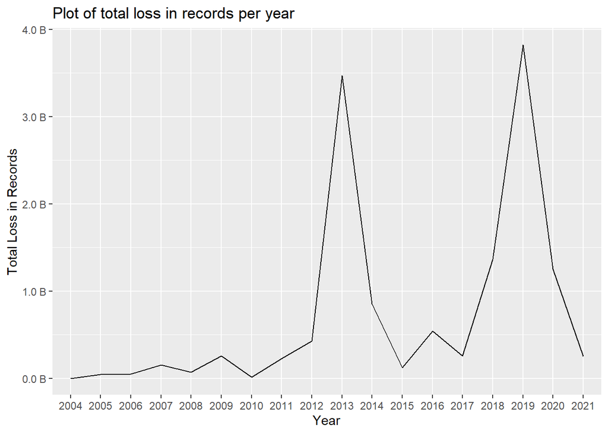

```r
# First Graph
data_breach %>%
  group_by(Year) %>%
  summarize(tot_lost = sum(Records)) %>%
  filter(Year != "2014 and 2015", Year != "2018-2019") %>%
  ggplot(aes(x = Year,
             y = tot_lost,
             group = 1)) +
  geom_line() +
  scale_y_continuous(labels = label_number(suffix = " B", scale = 1e-9)) +
  ylab("Total Loss in Records") +
  labs(title = "Plot of total loss in records per year")
```

For my second graph I decided to do a bar plot showing the total loss in records by Organization type. The organization type that has lost the most in data breaches are companies who deal with web services.

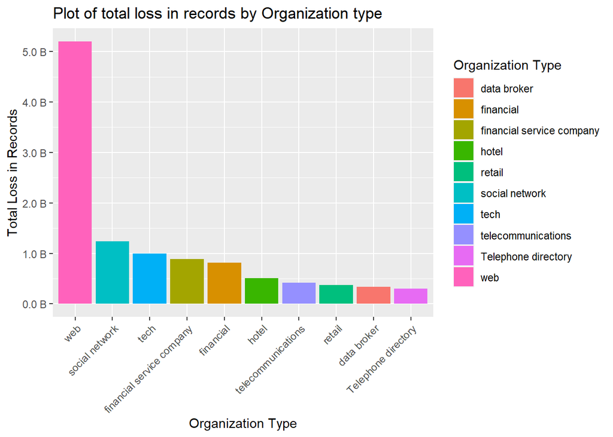

```r
# Second Graph
data_breach %>%
  group_by(Organization.type) %>%
  summarize(tot_lost = sum(Records)) %>%
  slice_max(order_by = tot_lost, n = 10) %>%
  ggplot(aes(fct_rev(fct_reorder(Organization.type, tot_lost)),
             tot_lost,
             fill = Organization.type)) +
  geom_bar(stat = "identity") +
  theme(axis.text.x = element_text(angle = 45, hjust = 1)) +
  scale_y_continuous(labels = label_number(suffix = " B", scale = 1e-9)) +
  xlab("Organization Type") +
  ylab("Total Loss in Records") +
  labs(title = "Plot of total loss in records by Organization type",
       fill = "Organization Type")
```

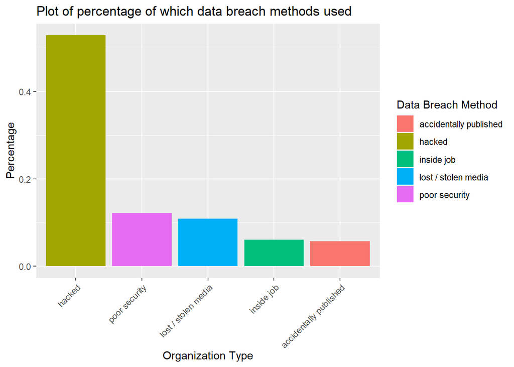

```r
# Third Graph
# Assigning new Data Frame for percentages
method_percentage <- data_breach %>%
  filter(!is.na(Method)) %>%
  group_by(Method) %>%
  summarize(n = n()) %>%
  mutate(total = sum(n),
         percentage = n/total,
         Method = factor(Method))

# Creating bar plot
method_percentage %>%
  slice_max(order_by = percentage, n = 5) %>%
  ggplot(aes(fct_rev(fct_reorder(Method, percentage)),
             percentage,
             fill = Method)) +
  geom_col(position = "dodge") +
  theme(axis.text.x = element_text(angle = 45, hjust = 1)) +
  xlab("Organization Type") +
  ylab("Percentage") +
  labs(title = "Plot of percentage of which data breach methods used",
       fill = "Data Breach Method")
```